# Нейронные сети и прогнозирование временного ряда.

©Alexander Doynikov,dep. CS, MSU

November 18, 2018

# Краткое введение в нейронные сети

Нейронная сеть это математическая модель построенная исходя из принципов функционирования головного мозга и представляет собой систему взаимодействующих между собой искусственных нейронов.Каждый нейрон имеет дело только с сигналами, которые он периодически получает, и сигналами, которые он периодически посылает другим нейронам. Нейронные сети позволяют решать статистические задачи классификации, кластеризации, прогнозирования временных рядов, задачи распознавания образов, моделирования естественного интеллекта.

Главное приемущество нейронных систем это возможность обучения, которое заключается в постепенном (в процессе обучения) оценке коэффициента связи с другими нейронами сети.

По построению нейронные сети можно поделить на однонаправленные, когда сигнал передается со слоя на слой последовательно, и на сети, где есть петли обратной связи. Однонаправленные сети гарантированно закончат свою работу. Поведение сетей с обратной связью, вообоще говоря, непредсказуемо. В этом случае следует принимать специальные меры к тому, чтобы сеть не зацикливалась.

Исторически первые появились сети на основе перцептрона - кибернетическая модель мозга, предложенной Фрэнком Розенблаттом в 1957 году.Перцептрон состоит из трёх типов элементов, а именно: поступающие от сенсоров сигналы передаются ассоциативным элементам, а затем реагирующим элементам.Чтобы «научить» перцептрон классифицировать образы, был разработан специальный итерационный метод обучения проб и ошибок, напоминающий процесс обучения человека — метод коррекции ошибки.

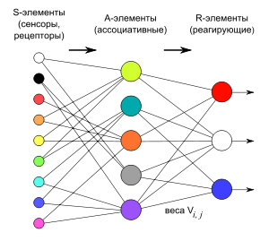

Логическая схема перцептрона представлена на рисунке.

Поступающая через вход информация обрабатывается в нейроне в 2 этапа: На первом этапе вычисляется взвешенная сумма:
$$S = \sum_{i=1}^n\omega_i X_i + O$$
Число О — порог.

Обычно, для унификации записи порог рассматривается как вес тупой связи, то есть связи которая все время генерирует 1. И тогда можно записать как:
$$S = \sum_{i=0}^n\omega_i X_i$$

где
$$X_0 = 1, \omega_0 = O$$
Это так называемый классический нейрон сокращенно КН.

В обобщённом КН выступают вероятностные меры, где число О — случ. величина чаше всего с нормальным распределением $N(0, G)$

Алгебраический нейрон это нейрон, где сумма S нелинейна.

Выход нейрона — $Y$. определяется как некоторая функция от взвешенной суммы.
$$y = f(s)$$
Функция $f$ — функция активации.

## Примеры функций активации

1.Простая кусочно-линейная функция. Если входное значение меньше порогового, то значение функции активации равно минимальному допустимому, иначе – максимально допустимому.

2.Несложная кусочно-линейная функция. Имеет два линейных участка, где функция активации тождественно равна минимально допустимому и максимально допустимому значению и есть участок, на котором функция строго монотонно возрастает.

3.Сигмоидальная функция или сигмоид.

Монотонно возрастающая всюду дифференцируемая S-образная нелинейная функция с насыщением. Сигмоид позволяет усиливать слабые сигналы и не насыщаться от сильных сигналов. Примером сигмоидальной функции активации может служить логистическая функция, задаваемая следующим выражением:
$$f(s)=\frac{1}{1+e^{-\alpha s}}$$

Еще одним примером сигмоидальной функции активации является гиперболический тангенс, задаваемый следующим выражением:
$$f(s)=tanh(s)=\frac{e^s-e^{-s}}{e^s+e^{-s}}$$

# Построение оптимальной архитектуры нейронной сети для проноза временного ряда

Сначала определимся с функцией активации Задача прогнозирования временного ряда сродни задачи регрессии, в которых чаще всего используется тождественная функция
$$y = f(x) = x$$
Здесь мы рассмотрим основную идею задания оптимальной архитектуры нейронной сети для прогнозирования временного ряда, модель которого известна. Предположим, что строится прогноз временного ряда $y_t$, заданного моделью авторегрегресии порядка 3 (AR(3)-модель).
$$y_t = \nu+\phi_1y_{t-1}+\phi_2y_{t-2}+\phi_3y_{t-3}+\epsilon_t$$
Исходя из вида модели AR(3) наиболее оптимальной архитектурой нейронной сети напрашивается сеть с 3 входами и одним выходом (относительно скрытого уровня нейронов поговорим позднее). Пусть временной ряд $y_t$ состоит из 24 наблюдений, $y_1,y_2,...,y_{23},y_{24}$ тогда расположим наблюдения $y_t$ в виде матрицы
$$\begin{equation*}\left[ \begin{matrix}\
y_1&y_2&y_3&y_4\\
y_2&y_3&y_4&y_5\\
y_3&y_4&y_5&y_6\\
...\\
y_{21}&y_{22}&y_{23}&y_{24}\\
\end{matrix}\right] \end{equation*}$$
Первые 3 столбца будем считать входом нейронной сети, а четвертый столбец выходом нейронной сети.

В сезонной моделе все гороаздо сложнее Для сезонного ряда авторегрессии с периодом сезоннсти $S=8$, и моделью
$$\Phi_2(B^S)\phi_2(B)y_t=\epsilon_t$$
где
$$\Phi_2(B^S)=1-\Phi_1B^S-\Phi_2B^{2S}$$
$$\phi_2(B)=1-\phi_1B-\phi_2B^2$$
Перемножая полинономы $\Phi_2(B^S)$ и $\phi_2(B)$, получим
$$\Phi_2(B^S)\phi_2(B)y_t=$$
$$(1-\Phi_1B^S-\Phi_2B^{2S}-\phi_1B-\phi_2B^{2}+\Phi_1\phi_1B^{S+1}+\Phi_1\phi_2B^{S+2}+\Phi_2\phi_1B^{2S+1}+\Phi_2\phi_2B^{2S+2})y_t$$
отсюда
$$y_t=\phi_1y_{t-1}+\phi_2y_{t-2}+\Phi_1y_{t-S}+\Phi_2y_{t-2S}-\Phi_1\phi_1y_{t-S-1}-\Phi_1\phi_2y_{t-S-2}-\Phi_2\phi_1y_{t-2S-1}-\Phi_2\phi_2y_{t-2S-2}$$
при периоде сезонности $S=8$
$$y_t=\phi_1y_{t-1}+\phi_2y_{t-2}+\Phi_1y_{t-8}-\Phi_1\phi_1y_{t-9}-\Phi_1\phi_2y_{t-10}+\Phi_2y_{t-16}-\Phi_2\phi_1y_{t-17}-\Phi_2\phi_2y_{t-18}$$
Таким образом вход и выход нейронной сети для ряда $y_1,y_2,...,y_{23},y_{24}$ в виде матрицы следует задать так
$$\begin{equation*}\left[ \begin{matrix}\
y_1&y_2&y_3&y_9&y_{10}&y_{11}&y_{17}&y_{18}&y_{19}\\
y_2&y_3&y_4&y_{10}&y_{11}&y_{12}&y_{18}&y_{19}&y_{20}\\
...\\
y_8&y_7&y_8&y_{14}&y_{15}&y_{16}&y_{22}&y_{23}&y_{24}\\
\end{matrix}\right] \end{equation*}$$
Крайний правый столбец это выход нейронной сети, а первые 8 столбцов это вход сети. Для работы с нейронными сетями в R обычно используется пакет `neuralnet`. Но подготовка архитектуры сети для учета автокорреляционных связей во временном ряде весьма трудоемкая в программном смысле задача.

# Пакет forecast

`forecast` — это пакет, написанный Робом Хайндманом (Rob J. Hyndman), содержит различные методы прогнозирования временных рядов, включая и знакомые нам уже ARMA и SARMA прогнозирование. Но мы из этого пакета коснемся только одного метода прогнозирования временного ряда посредством нейронных сетей `nnetar()`. В нем эта неприятная процедура построения входа и выхода для сезонных временных рядов реализована, что значительно облегчает труд программиста.

```r
library(forecast)
```

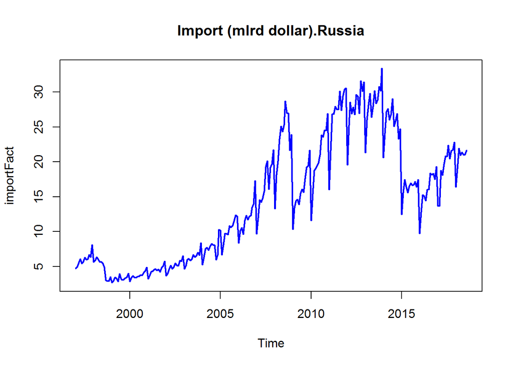

```r
 import <- read.csv("./import.csv", header = TRUE)
 importFact <- ts(import$Fact ,start= c(1997,1),frequency =12)
 plot(importFact ,type = "l", col = "blue",lwd = 2,main = "Import (mlrd dollar).Russia")
```

Обучим нейронную сеть

```r
  p <- 5
  P <- 3
  library(forecast)
  nnet<- nnetar(importFact,p=p,P = P,size = 10 )
```

Количество нейронов в скрытом уровне мы взяли равным 10. Построим прогноз на год вперед

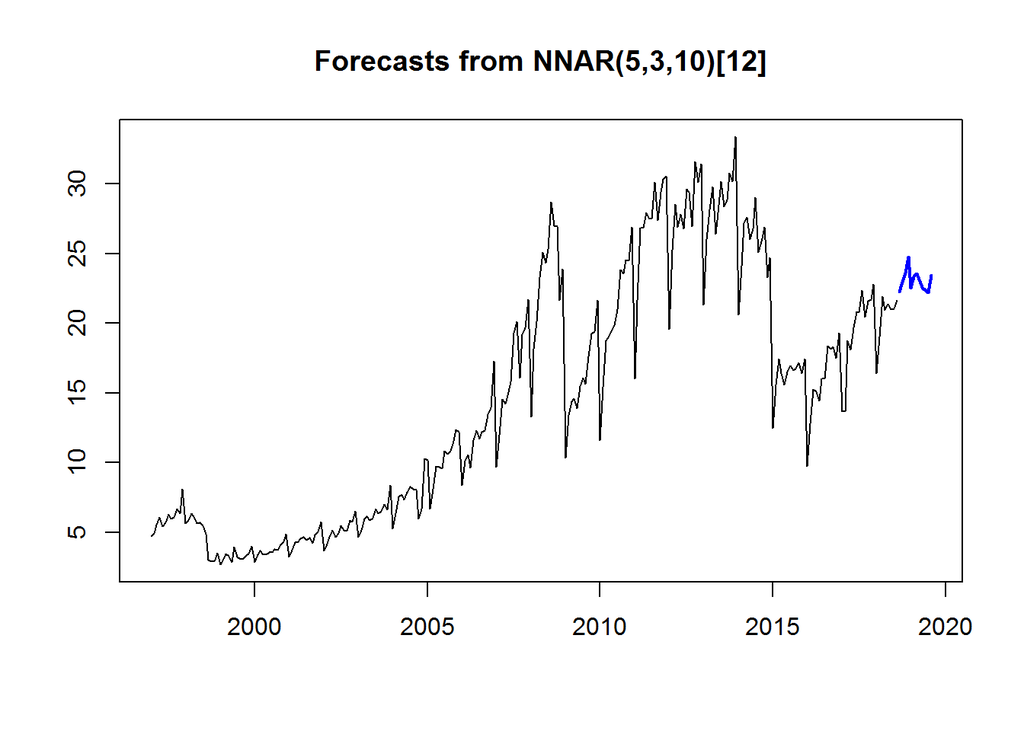

```r
fcast <- forecast(nnet,h = 12)
plot(fcast)
```

```r
summary(nnet)
```

```
##           Length Class        Mode
## x         260    ts           numeric
## m           1    -none-       numeric
## p           1    -none-       numeric
## P           1    -none-       numeric
## scalex      2    -none-       list
## size        1    -none-       numeric
## subset    260    -none-       numeric
## model      20    nnetarmodels list
## nnetargs    0    -none-       list
## fitted    260    ts           numeric
## residuals 260    ts           numeric
## lags        8    -none-       numeric
## series      1    -none-       character
## method      1    -none-       character
## call        5    -none-       call
```

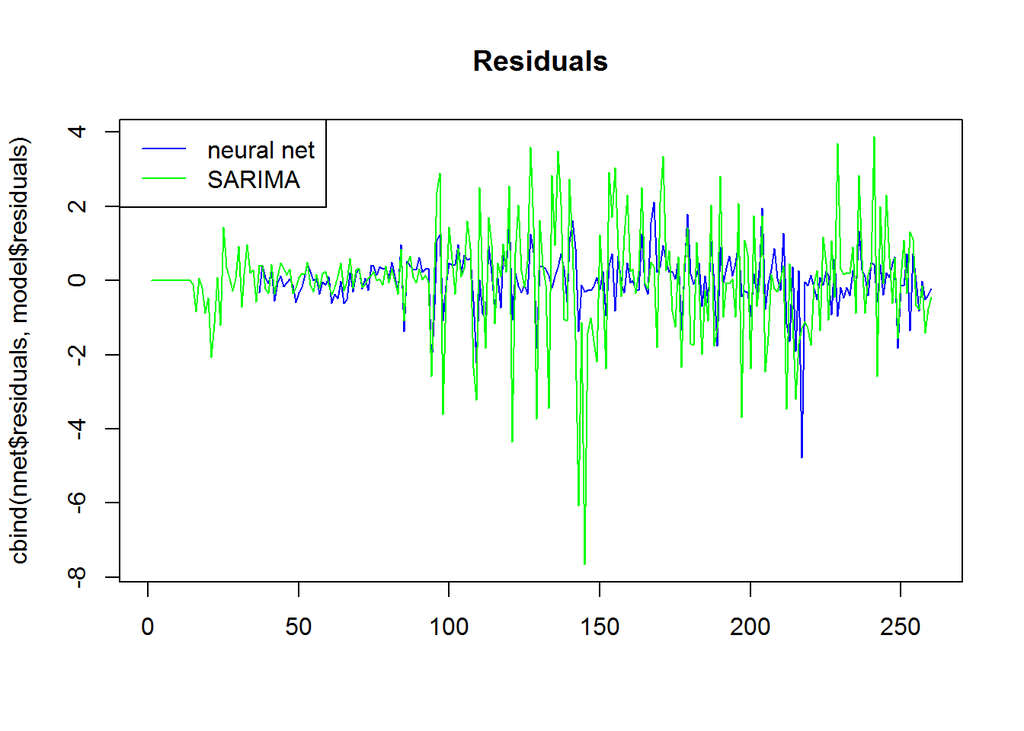

```r
model <-arima(importFact,order = c(0,1,1),seasonal = list(order = c(0,1,3),period=12), method="CSS")

matplot(cbind(nnet$residuals,model$residuals),type = 'l',main = 'Residuals', lty= 1,col = c("blue",'green'))
legend('topleft',c('neural net','SARIMA'),lty = 1,col = c("blue",'green'))
```

```r
mean(nnet$residuals[100:241]^2)
```

```
## [1] 0.7220099
```

```r
mean(model$residuals[100:241]^2)
```

```
## [1] 3.394925
```

```r
nnet$model
```

```
##
## Average of 20 networks, each of which is
## a 8-10-1 network with 101 weights
## options were - linear output units
```